# netOmics

pepe

4/5/2022

Se instalan las librerias necesarias para correr el analisis de netOMics

```r
# instalar el paquete por github
library(devtools)
#install_github("abodein/netOmics")
```

```r
library(netOmics)
```

```r
#if (!require("BiocManager", quietly = TRUE))
#    install.packages("BiocManager")

#BiocManager::install("timeOmics")

#install_github("zdk123/SpiecEasi")

library(timeOmics)
library(tidyverse)
```

```r
library(igraph)
library(SpiecEasi)
```

Ahora se cargan los datos del ejemplo de diabetes estacionaria

```r
# load data
data("hmp_T2D")
```

Primero se obtienen los dos clusters y las interacciones del RNA por medio del algoritmo ARACNe

```r
cluster.info <- hmp_T2D$getCluster.res
```

```r
cluster.info.RNA <- timeOmics::getCluster(cluster.info, user.block = "RNA")
graph.rna <- get_grn(X = hmp_T2D$data$RNA, cluster = cluster.info.RNA)
# informacion de la grafica
get_graph_stats(graph.rna)
```

```
##     node.c node.i  edge edge.density type:gene mode:core cluster:-1 cluster:1
## All    759     16 70539    0.2351888       775       775        610       165
## 1      155     10  2922    0.2159645       165       165         NA       165
## -1     595     15 61000    0.3284072       610       610        610        NA
```

Ahora se infiere la red y los clusters de las proteinas por medio de la base de de datos de biogrid

```r
get_list_mol_cluster <- function(cluster.info, user.block){
  require(timeOmics)
    tmp <- timeOmics::getCluster(cluster.info, user.block)
    res <- tmp %>% split(.$cluster) %>%
        lapply(function(x) x$molecule)
    res[["All"]] <- tmp$molecule
    return(res)
}
cluster.info.prot <- get_list_mol_cluster(cluster.info, user.block = 'PROT')
graph.prot <-  get_interaction_from_database(X = cluster.info.prot,
                                             db = hmp_T2D$interaction.biogrid,
                                             type = "PROT", user.ego = TRUE)
get_graph_stats(graph.prot)
```

```
##     node.c node.i edge edge.density mode:core mode:extended type:PROT
## 1      155      0  154  0.012903226         8           147       155
## -1     798      0  893  0.002808150        14           784       798
## All    912      0 1044  0.002513143        22           890       912
```

Ahora se hace el procedimieto para los otu de intestino, en este caso se utiliza el algoritmo sparCC del paquete SpiecEasi

```r
get_sparcc_graph <- function(X, threshold = 0.3){
    res.sparcc <- sparcc(data = X)
    sparcc.graph <- abs(res.sparcc$Cor) >= threshold
    colnames(sparcc.graph) <-  colnames(X)
    rownames(sparcc.graph) <-  colnames(X)
    res.graph <- graph_from_adjacency_matrix(sparcc.graph,
                                             mode = "undirected") %>% simplify
    return(res.graph)
}
gut_list <- get_list_mol_cluster(cluster.info, user.block = 'GUT')
graph.gut <- list()
graph.gut[["All"]] <- get_sparcc_graph(hmp_T2D$raw$GUT, threshold = 0.3)
graph.gut[["1"]] <- get_sparcc_graph(hmp_T2D$raw$GUT %>%
                                       dplyr::select(gut_list[["1"]]),
                                     threshold = 0.3)
graph.gut[["-1"]] <- get_sparcc_graph(hmp_T2D$raw$GUT %>%
                                        dplyr::select(gut_list[["-1"]]),
                                      threshold = 0.3)
class(graph.gut) <- "list.igraph"
```

```r
graph.gut <- hmp_T2D$graph.gut
get_graph_stats(graph.gut)
```

```
##     node.c node.i edge edge.density
## All     35     23   30   0.01814882
## 1       12     21    8   0.01515152
## -1      12     13    6   0.02000000
```

Posteirormente se infiere la red de el metaboloma, las variables clinicas y se construye de biogrid la red de las citocinas

```r
# construccion de las citocinas
cyto_list = get_list_mol_cluster(cluster.info = cluster.info,
                                 user.block = "CYTO")
graph.cyto <-  get_interaction_from_database(X = cyto_list,
                                             db = hmp_T2D$interaction.biogrid,
                                             type = "CYTO", user.ego = TRUE)
get_graph_stats(graph.cyto)
```

```
##     node.c node.i edge edge.density mode:core mode:extended type:CYTO
## 1       18      0   17   0.11111111         3            15        18
## -1      30      0   27   0.06206897         4            26        30
## All     46      0   44   0.04251208         7            39        46
```

```r
# Inferencia del metaboloma
cluster.info.metab <-  timeOmics::getCluster(X = cluster.info,
                                             user.block = "METAB")
graph.metab <-  get_grn(X = hmp_T2D$data$METAB,
                        cluster = cluster.info.metab)
get_graph_stats(graph.metab)
```

```
##     node.c node.i edge edge.density type:gene mode:core cluster:-1 cluster:1
## All     43     62   75   0.01373626       105       105         49        56
## 1       22     34   41   0.02662338        56        56         NA        56
## -1      11     38   21   0.01785714        49        49         49        NA
```

```r
# Inferencia clinica
cluster.info.clinical <- timeOmics::getCluster(X = cluster.info,
                                               user.block = 'CLINICAL')
graph.clinical <- get_grn(X = hmp_T2D$data$CLINICAL,
                          cluster = cluster.info.clinical)
get_graph_stats(graph.clinical)
```

```
##     node.c node.i edge edge.density type:gene mode:core cluster:-1 cluster:1
## All      6     33    4  0.005398111        39        39         22        17
## 1        2     15    1  0.007352941        17        17         NA        17
## -1       4     18    2  0.008658009        22        22         22        NA
```

Ahora se combinan las capas creadas con la funcion combine_layers, primero se van a combinar las capas del proteoma, las citocinas y los FT

```r
full.graph <- combine_layers(graph1 = graph.rna, graph2 = graph.prot)
full.graph <- combine_layers(graph1 = full.graph, graph2 = graph.cyto)
full.graph <- combine_layers(graph1 = full.graph,
                             graph2 = hmp_T2D$interaction.TF)
 get_graph_stats(full.graph)
```

```
##     node.c node.i   edge edge.density cluster:-1 cluster:1 type:CYTO type:gene
## All   1676      7 140004   0.09891458        610       165        36       775
## 1      327      6   6798   0.12297840         NA       165        16       165
## -1    1402      2 108557   0.11022067        610        NA        24       610
##     type:PROT mode:core mode:extended
## All       872       804           879
## 1         152       176           157
## -1        770       628           776
```

Ahora se van a unir las capas que no tienen interacciones descritas, sino que fueron inferidas, para estas capas se utilizan correlaciones entre los datos inferidos y los datos descritos

```r
all_data <- reduce(hmp_T2D$data, cbind)
# Microbioma
gut_list <- get_list_mol_cluster(cluster.info, user.block = "GUT")
omic_data <- lapply(gut_list, function(x)dplyr::select(hmp_T2D$data$GUT, x))
```

```
## Note: Using an external vector in selections is ambiguous.
## i Use `all_of(x)` instead of `x` to silence this message.
## i See <https://tidyselect.r-lib.org/reference/faq-external-vector.html>.
```

```r
# RNA, PROT, CYTO
other_data_list <- get_list_mol_cluster(cluster.info,
                                        user.block = c("RNA", "PROT", "CYTO"))
other_data <- lapply(other_data_list, function(x)dplyr::select(all_data, x))
# Interaccion entre microbioma y RNA, PROT y CYTO
interaction_df_gut <- get_interaction_from_correlation(X = omic_data,
                                                       Y = other_data,
                                                       threshold = 0.99)
# Se une a la grafica completa
full.graph <- combine_layers(graph1 = full.graph,
                             graph2 = graph.gut,
                             interaction.df = interaction_df_gut$All)
```

Se unuen los datos clinicos

```r
# Datos clinicos
clinical_list <- get_list_mol_cluster(cluster.info, user.block = "CLINICAL")
omic_data <- lapply(clinical_list,
                    function(x)dplyr::select(hmp_T2D$data$CLINICAL, x))
# otros datos, con la grafica obtenida antes
other_data_list <- get_list_mol_cluster(cluster.info,
                                        user.block = c("RNA", "PROT",
                                                       "CYTO", "GUT"))
other_data <- lapply(other_data_list, function(x)dplyr::select(all_data, x))
# Interaccion entre los otros datos y los datos clinicos
interaction_df_clinical <- get_interaction_from_correlation(X = omic_data
                                                            , Y = other_data,
                                                            threshold = 0.99)
# Se une con toda la grafica
full.graph <- combine_layers(graph1 = full.graph,
                             graph2 = graph.clinical,
                             interaction.df = interaction_df_clinical$All)
```

Se Unen los datos del metaboloma

```r
# Metaboloma
metab_list <- get_list_mol_cluster(cluster.info, user.block = "METAB")
omic_data <- lapply(metab_list, function(x)dplyr::select(hmp_T2D$data$METAB, x))
# Los demas datos
other_data_list <- get_list_mol_cluster(cluster.info,
                                        user.block = c("RNA", "PROT", "CYTO",
                                                       "GUT", "CLINICAL"))
other_data <- lapply(other_data_list, function(x)dplyr::select(all_data, x))
# Interacciones de todos los datos omicos
interaction_df_metab <- get_interaction_from_correlation(X = omic_data,
                                                         Y = other_data,
                                                         threshold = 0.99)
# Se une todo
full.graph <- combine_layers(graph1 = full.graph,
                             graph2 = graph.metab,
                             interaction.df = interaction_df_metab$All)
```

Ahora que se unieron todas las capas se va a hacer el Over Representation Analysis ORA en donde se introducen los datos de gene ontology GO, pero solo con las capas que cuenta con esta informacion, se utiliza la funcion get_interaction_from_ORA

```r
# ORA por cluster
mol_ora <- get_list_mol_cluster(cluster.info,
                                user.block = c("RNA", "PROT", "CYTO"))
# Se obtienen las interacciones ORA por cluster
graph.go <- get_interaction_from_ORA(query = mol_ora,
                                     sources = "GO",
                                     organism = "hsapiens",
                                     signif.value = TRUE)
# se unen
full.graph <- combine_layers(graph1 = full.graph, graph2 = graph.go)
```

Ademas del analisis ORA, tambien se añadio informacion adicional de medline ranker

```r
# medlineRanker -> datos
medlineranker.res.df <- hmp_T2D$medlineranker.res.df %>%
  dplyr::select(Disease, symbol) %>%
  set_names(c("from", "to"))

mol_list <-  get_list_mol_cluster(cluster.info = cluster.info,
                                  user.block = c("RNA", "PROT", "CYTO"))
graph.medlineranker <-  get_interaction_from_database(X = mol_list,
                                                      db = medlineranker.res.df,
                                                      type = "Disease",
                                                      user.ego = TRUE)
get_graph_stats(graph.medlineranker)
```

```
##     node.c node.i edge edge.density mode:core mode:extended type:Disease
## 1      167      0  266   0.01919053        57           110          167
## -1     378      0  773   0.01084867       204           174          378
## All    439      0 1039   0.01080704       261           178          439
```

```r
# Union
full.graph <- combine_layers(graph1 = full.graph, graph2 = graph.medlineranker)
```

Se completo la preparacion de la red multiomica, tomando en cuenta estas caracteristicas.

- mode = “core” if the vertex was originally present in the data; “extended” otherwise
- sparse = TRUE if the vertex was present in kinetic cluster signature; FALSE otherwise
- type = type of omics (“RNA”,“PROT”,“CLINICAL”,“CYTO”,“GUT”,“METAB”,“GO”, “Disease”)
- cluster = ‘1’, ‘-1’ or ‘NA’ (for vertices not originally present in the original data)

```r
# graph cleaning
graph_cleaning <- function(X, cluster.info){
    # no reusability
    X <- igraph::simplify(X)
    va <- vertex_attr(X)
    viewed_mol <- c()
    for(omic in unique(cluster.info$block)){
        mol <- intersect(cluster.info %>% dplyr::filter(.$block == omic) %>%
                           pull(molecule), V(X)$name)
        viewed_mol <- c(viewed_mol, mol)
        X <- set_vertex_attr(graph = X,
                             name = "type",
                             index = mol,
                             value = omic)
        X <- set_vertex_attr(graph = X,
                             name = "mode",
                             index = mol,
                             value = "core")
    }
    # add medline ranker and go
    mol <- intersect(map(graph.go, ~ as_data_frame(.x)$to) %>%
                       unlist %>% unique(), V(X)$name) # only GO terms
    viewed_mol <- c(viewed_mol, mol)
    X <- set_vertex_attr(graph = X, name = "type", index = mol, value = "GO")
    X <- set_vertex_attr(graph = X, name = "mode",
                         index = mol, value = "extended")

    mol <- intersect(as.character(medlineranker.res.df$from), V(X)$name)
    viewed_mol <- c(viewed_mol, mol)
    X <- set_vertex_attr(graph = X, name = "type",
                         index = mol, value = "Disease")
    X <- set_vertex_attr(graph = X, name = "mode",
                         index = mol, value = "extended")

    other_mol <- setdiff(V(X), viewed_mol)
    if(!is_empty(other_mol)){
        X <- set_vertex_attr(graph = X, name = "mode",
                             index = other_mol, value = "extended")
    }
    X <- set_vertex_attr(graph = X, name = "mode",
                         index = intersect(cluster.info$molecule, V(X)$name),
                         value = "core")

    # signature
    mol <-  intersect(V(X)$name, hmp_T2D$getCluster.sparse.res$molecule)
    X <- set_vertex_attr(graph = X, name = "sparse", index = mol, value = TRUE)
    mol <-  setdiff(V(X)$name, hmp_T2D$getCluster.sparse.res$molecule)
    X <- set_vertex_attr(graph = X, name = "sparse", index = mol, value = FALSE)

    return(X)
}
```

```r
FULL <- lapply(full.graph, function(x) graph_cleaning(x, cluster.info))
get_graph_stats(FULL)
```

```
##     node.c node.i  edge edge.density cluster:-1 cluster:1 type:CLINICAL
## All   2115    123 89483   0.03574740        681       238            39
## 1      492     76  5569   0.03458405         NA       238            18
## -1    1725     69 62454   0.03883180        681        NA            22
##     type:CYTO type:Disease type:GO type:GUT type:METAB type:PROT type:RNA
## All        37          178     174       58        105       872      775
## 1          15          110      17       33         56       150      169
## -1         24          174     121       25         49       758      621
##     mode:core mode:extended sparse:FALSE sparse:TRUE
## All      1009          1229         2134         104
## 1         292           276          523          45
## -1        738          1056         1734          60
```

Se pueden ver estadisticas basicas de la red como degree distribution, modularity, y short path

```r
# degree analisis
d <- degree(FULL$All)
hist(d)
d[max(d)]
# modularity
res.mod <- edge.betweenness.community(FULL$All)
res.mod <- walktrap.community(FULL$All)
# ...
# modularity
sp <- shortest.paths(FULL$All)
```

```r
seeds <- head(V(FULL$All)$name[V(FULL$All)$type == "GO"])
rwr_res <- random_walk_restart(FULL, seeds)
```

Tambien se puede analizar que nodos interactuan con varias capas omicas con poca distancia, la funcion “rwr_find_seeds_between_attributes” puede encontrar que semillas van a tener mucho atributos con pocas conexiones.

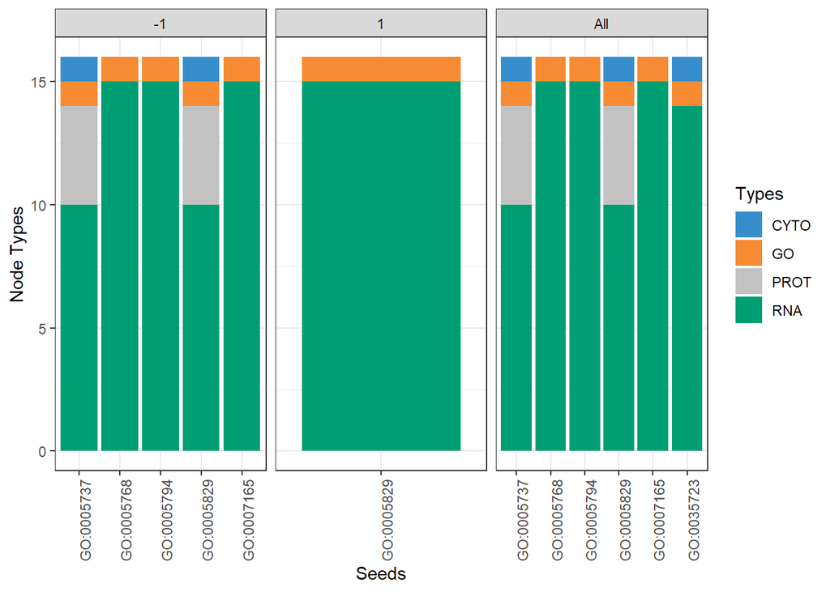

```r
rwr_type_k15 <- rwr_find_seeds_between_attributes(X = rwr_res,
                                                  attribute = "type", k = 15)

summary_plot_rwr_attributes(rwr_type_k15)
```

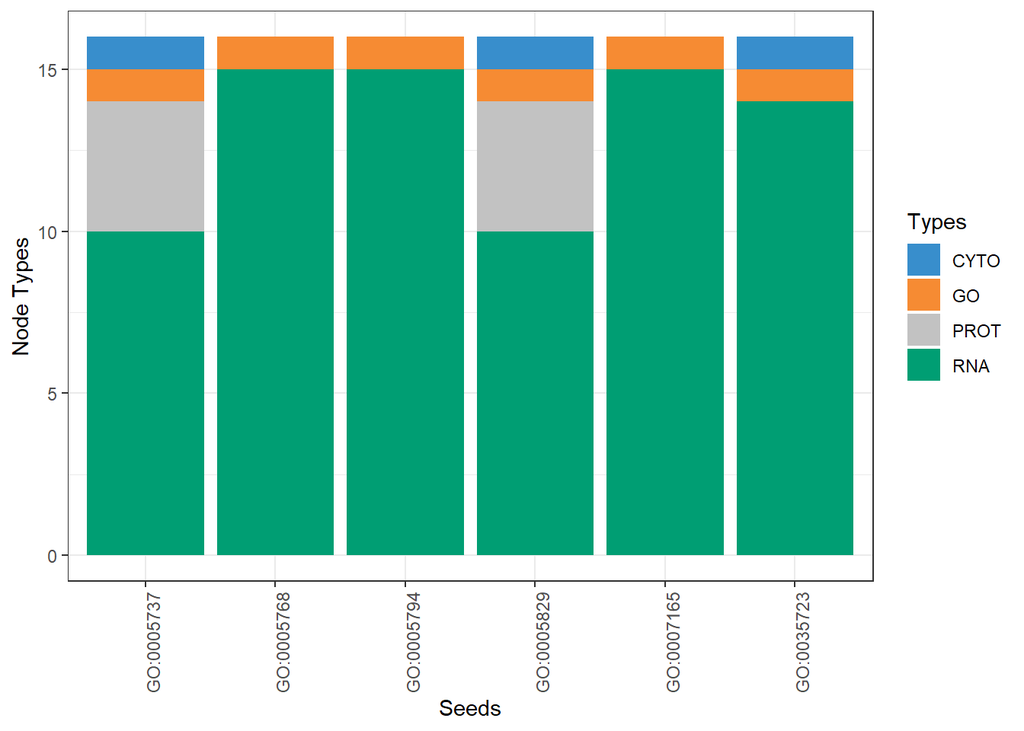

```r
summary_plot_rwr_attributes(rwr_type_k15$All)
```

O tambien se pueden buscar nodos que interactuen con diferentes clusters

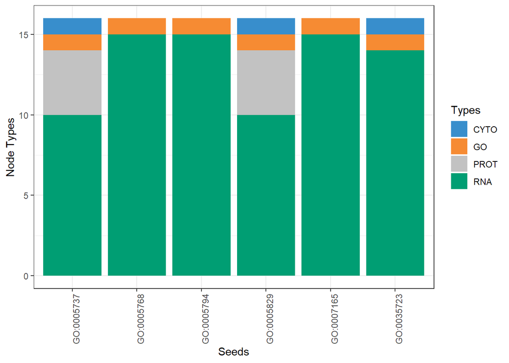

```r
rwr_type_k15 <- rwr_find_seeds_between_attributes(X = rwr_res$All,
                                                  attribute = "cluster", k = 15)
summary_plot_rwr_attributes(rwr_type_k15)
```

Tambien se pueden crear subredes de nodos especificos

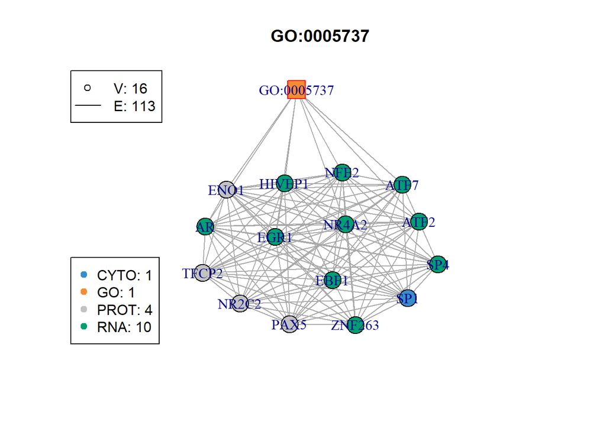

```r
sub_res <- rwr_type_k15$`GO:0005737`
sub <- plot_rwr_subnetwork(sub_res, legend = TRUE, plot = TRUE)
```

Por ultimo se puede predecir la funcion de un nodo no anotado al hacer el analisis random walk con ese nodo como semilla y ver por ejemplo cuales son los 5 elementos GO mas cercanos a esa semilla para determinar su función. Tambien se puede hacer con capas

```r
rwr_res <- random_walk_restart(FULL$All, seed = "ZNF263")
# closest GO term
rwr_find_closest_type(rwr_res, seed = "ZNF263", attribute = "type",
                      value = "GO", top = 5)
```

```
## $ZNF263
## # A tibble: 5 x 7
##   NodeNames        Score SeedName cluster type  mode     sparse
##   <chr>            <dbl> <chr>    <chr>   <chr> <chr>    <lgl>
## 1 GO:0008022 0.00000988  ZNF263   <NA>    GO    extended FALSE
## 2 GO:0012505 0.00000983  ZNF263   <NA>    GO    extended FALSE
## 3 GO:0044877 0.00000961  ZNF263   <NA>    GO    extended FALSE
## 4 GO:0048583 0.000000978 ZNF263   <NA>    GO    extended FALSE
## 5 GO:0060997 0.000000962 ZNF263   <NA>    GO    extended FALSE
##
## attr(,"class")
## [1] "rwr.closest"
```

```r
# closest Disease
rwr_find_closest_type(rwr_res, seed = "ZNF263", attribute = "type",
                      value = "Disease", top = 5)
```

```
## $ZNF263
## # A tibble: 5 x 7
##   NodeNames                          Score SeedName cluster type    mode  sparse
##   <chr>                              <dbl> <chr>    <chr>   <chr>   <chr> <lgl>
## 1 Carcinoma, Renal Cell        0.000000970 ZNF263   <NA>    Disease exte~ FALSE
## 2 Hypogonadism                 0.000000968 ZNF263   <NA>    Disease exte~ FALSE
## 3 Nasopharyngeal Neoplasms     0.000000959 ZNF263   <NA>    Disease exte~ FALSE
## 4 Familial Mediterranean Fever 0.000000954 ZNF263   <NA>    Disease exte~ FALSE
## 5 Spondylitis, Ankylosing      0.000000954 ZNF263   <NA>    Disease exte~ FALSE
##
## attr(,"class")
## [1] "rwr.closest"
```

```r
# closest nodes with an attribute "cluster" and the value "-1"
rwr_find_closest_type(rwr_res, seed = "ZNF263", attribute = "cluster",
                      value = "-1", top = 5)
```

```
## $ZNF263
## # A tibble: 5 x 7
##   NodeNames       Score SeedName cluster type  mode  sparse
##   <chr>           <dbl> <chr>    <chr>   <chr> <chr> <lgl>
## 1 ATF7      0.000880    ZNF263   -1      RNA   core  FALSE
## 2 TET1      0.000824    ZNF263   -1      RNA   core  FALSE
## 3 LOC642943 0.00000940  ZNF263   -1      RNA   core  FALSE
## 4 LOC284801 0.00000506  ZNF263   -1      RNA   core  FALSE
## 5 ROR1.AS1  0.000000820 ZNF263   -1      RNA   core  FALSE
##
## attr(,"class")
## [1] "rwr.closest"
```